# Analysis - Car Selling Price

Soren Laney

October 25, 2022

```r
#first linear model of the data.

lm.cars <- lm(Price ~ Mileage, data=df)
# model <- summary(lm.cars)
# model

# plot(Price ~ Mileage, data=df)
# abline(lm.cars)


#plot(lm.cars)

#
# boxCox(lm.cars)
#
#
#
# y = sqrt(sqrt(df$Price))
#
# lm_new <- lm(y ~ df$Mileage)
# summary(lm_new)
#
# plot(lm_2, which=1)
#plot(lm_new, which=1)
#plot(lm_new)
#

#plot(sqrt(sqrt(Price)) ~ Mileage, data=df)
# abline(lm_2)
#abline(lm_new)
# abline(4.20957099+0.2258 , -0.02893911, lty=2)

# abline(4.20957099-0.2258 , -0.02893911, lty=2)

## Make it meaningful!


#abline(lm.cars)
```

## Conclusion

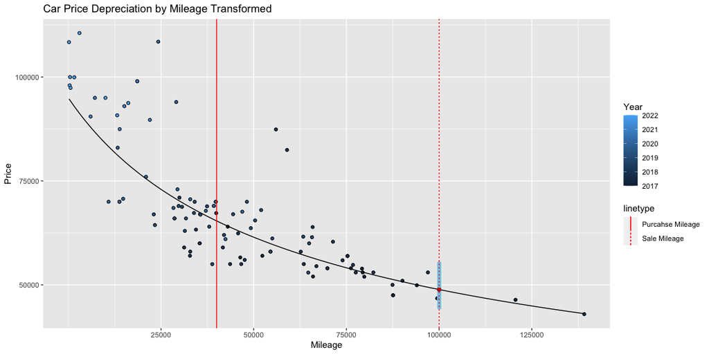

```r
#y = sqrt(sqrt(df$Price))
y = (df$Price)^-2

lm_new <- lm(y ~ df$Mileage)
b <- coef(lm_new)


car <- lm(y ~ Mileage, data=df)

pred <- (predict(car, data.frame(Mileage=100000), interval="prediction"))^-(1/2)


last_plot <- ggplot(df, aes(x=Mileage, y=Price))+
  geom_point(shape=21, aes(fill=Year))+
  #geom_smooth(method="lm", se=F, formula=y~x, fullrange=TRUE)+
  geom_segment(aes(x=100000, xend=100000, y=pred[2], yend=pred[3]), lwd=2, color="skyblue", alpha=.05)+
  stat_function(fun = function(x) ((b[1] + b[2]*x)^-(1/2)), color='black')+
  geom_segment(aes(x=100000, xend=100000, y=pred[2], yend=pred[3]), lwd=2, color="skyblue", alpha=.0005)+
geom_point(aes(x=100000,y=48875.13),colour="firebrick")+
  geom_vline(aes(xintercept=40000, linetype="Purcahse Mileage"), color="red")+
  geom_vline(aes(xintercept=100000, linetype="Sale Mileage"), color="red")+
  ggtitle("Car Price Depreciation by Mileage Transformed")+
  scale_x_continuous(breaks = c(25000, 50000, 75000, 100000, 125000))+
  scale_y_continuous(breaks = c(25000, 50000, 75000, 100000, 125000))

last_plot
```

```r
#transformed summary
pander(summary(lm_new))
```

|  | Estimate | Std. Error | t value | Pr(>\|t\|) |
| --- | --- | --- | --- | --- |
| **(Intercept)** | 1.108e-10 | 8.55e-12 | 12.96 | 1.636e-23 |
| **df$Mileage** | 3.078e-15 | 1.623e-16 | 18.96 | 1.09e-35 |

Fitting linear model: y ~ df$Mileage

| Observations | Residual Std. Error | $R^2$ | Adjusted $R^2$ |
| --- | --- | --- | --- |
| 107 | 4.578e-11 | 0.774 | 0.7718 |

## Hypothesis

This data was collected from from cars.com on the 30th(roughly) of September 2022. The data was focused on ford F-150’s with the Raptor Trim. It should be noted that besides the based F-150 frame on the truck, virtually everything else about this vehicle is different. This is important to note because this analysis will be focued on analyzing the depreciation of thjis specific vehicle over the miles driven and will mostly likely not be accurate in regards to other F-150 trucks of different trims.

Hypothesis - The Null hypothesis is that there not be a correlation between the mileage and the price of the vehicle. The Alternative being that there is a correlation that indicates what the price will be at a certain mileage of a vehicle or in this case the F-150 being observed.

$$H_0:\beta_1 = 0\\
H_a:\beta_1 \neq 0$$

The true regression model assumed by a regression analysis is given by

$$\underbrace{{Y_i}}_\text{Actual Price} =
\overbrace{\beta_0}^\text{y-int} + \overbrace{\beta_1}^\text{slope}
\underbrace{X_i}_\text{Mileage} + \epsilon_i \quad \text{where} \
\epsilon_i \sim N(0, \sigma^2)$$

With ${\beta_0}$ representing the sale price high and the ${\beta_1}$ representing the depreciation value as mileage increases. The estimated regression line obtained from a transformed regression analysis, pronounced “y-hat”, is written as

$$\underbrace{\hat{Y}^{-2}_i}_\text{Predicted Transformed Price} =
\overbrace{1.108e-10}^\text{est. y-int} +
\overbrace{3.078e-15}^\text{est. slope} \underbrace{X_i}_\text{Mileage}$$

The following is the equation transformed back to represent the actual values of the line in this data set. It is gathered by taking the inverse of $Y^{-2}$ which is represented by $Y^{-1/2}$.

$$\underbrace{\hat{Y}_i}_\text{Predicted Price} = \frac{ 1 }{\sqrt{
{{1.108e-10}} + {3.078e-15} {X_i}}}$$

## Data

This is the summary for the linear model of the Price plotted against the mileage.

```r
#first linear model of the data.

lm.cars <- lm(Price ~ Mileage, data=df)
model <- summary(lm.cars)
pander(model)
```

|  | Estimate | Std. Error | t value | Pr(>\|t\|) |
| --- | --- | --- | --- | --- |
| **(Intercept)** | 87772 | 1828 | 48.01 | 2.848e-73 |
| **Mileage** | -0.4472 | 0.03471 | -12.88 | 2.367e-23 |

Fitting linear model: Price ~ Mileage

| Observations | Residual Std. Error | $R^2$ | Adjusted $R^2$ |
| --- | --- | --- | --- |
| 107 | 9788 | 0.6126 | 0.6089 |

We can see in the graph below that the data would fit the line very well if it wasn’t for the vehicles mad within the last couple of years. The discrepancy is most likely because Ford released a new model of this vehicle that has a V8 option that is increasing the price and manipulating the data. This is why we will be preforming a transformation to the line so that is will fit the data better.

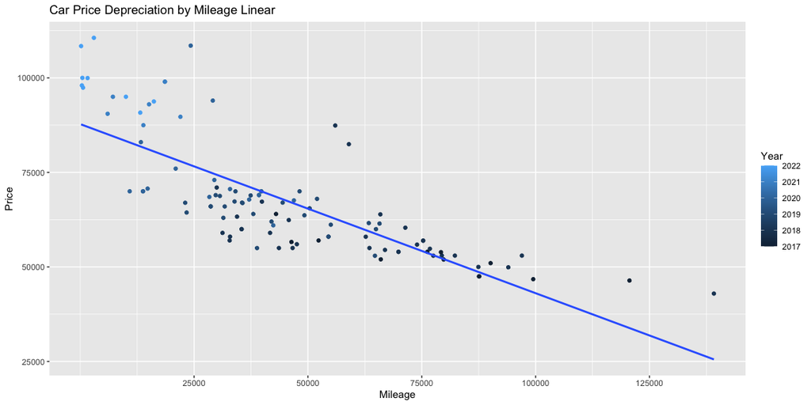

```r
lm_plot <- ggplot(df, aes(x=Mileage, y=Price, color=Year))+
  geom_point()+
  geom_smooth(method="lm", se=F, formula=y~x, fullrange=TRUE)+
  scale_x_continuous(breaks = c(25000, 50000, 75000, 100000, 125000))+
  scale_y_continuous(breaks = c(25000, 50000, 75000, 100000, 125000))+
  ggtitle("Car Price Depreciation by Mileage Linear")


lm_plot
```

```r
#abline(lm.cars)
#plot(lm.cars)
#shape=21, aes(fill=Year)
```

The graph below represents the box-cox transformation that is recommended for this data set. Box Cox transformation use a algorithm to manipulate a linear model to confirm with non-linear data. This transformation allows for a more accurate and meaningful model to fit to the data. The Box-cox transformation graph indicates a transformation of -2 to fit the model to the data. Since the data for cars is normally not linear we will be applying a transformation of $Y' = Y^{-2}$ to the data. This will make, or “bend”, the linear model to better confirm with the data and have a more meaningful value.

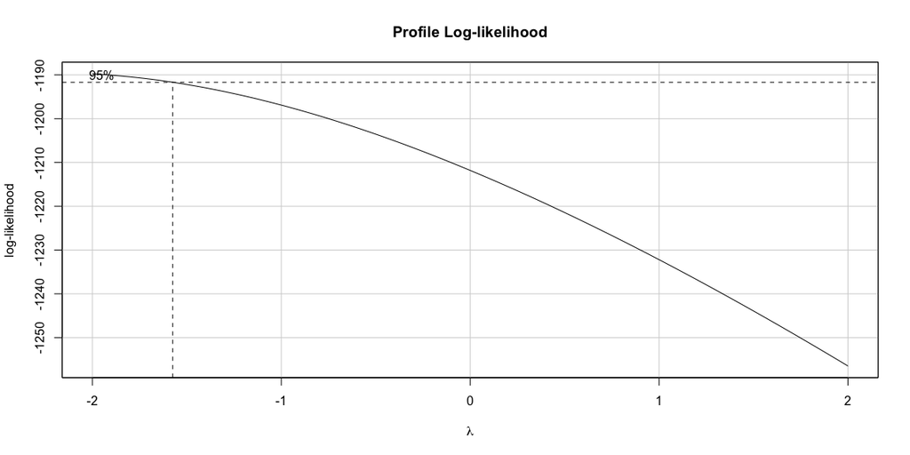

```r
boxCox(lm.cars)

#
#
# y = sqrt(sqrt(df$Price))
#
# lm_new <- lm(y ~ df$Mileage)
# summary(lm_new)

# plot(lm_2, which=1)
# plot(lm_new, which=1)
#plot(lm_new)


#plot(sqrt(sqrt(Price)) ~ Mileage, data=df)
#abline(lm_2)
#abline(lm_new)
#abline(4.20957099+0.2258 , -0.02893911, lty=2)

abline(4.20957099-0.2258 , -0.02893911, lty=2)
```

```r
## Make it meaningful!


#abline(lm.cars)
```

#### Data Set

This is the first five rows of the dataset.The data was collected from cars.com for F-150 raptors for within 250 miles of Rexburg, Idaho. I initially gathered the data for the trim in case there were not enough data point, or trucks for sale, of the trim that I wanted to do my analysis for.

```r
# Imported Data sets from CSV files.

df <- read_csv("/Users/soren.laney/Desktop/Fall Semester 2022/Math 425 Applied Linear Regression/Analysis/Car Selling Analysis/Data/Used Car Prices Data.csv")
df %>% head(5) %>% pander()
```

| Make | Model | Trim | Year | Price | Mileage |
| --- | --- | --- | --- | --- | --- |
| Ford | F-150 | Raptor | 2022 | 110590 | 3001 |
| Ford | F-150 | Raptor | 2022 | 108405 | 193 |
| Ford | F-150 | Raptor | 2022 | 99997 | 470 |
| Ford | F-150 | Raptor | 2022 | 99947 | 1615 |
| Ford | F-150 | Raptor | 2022 | 97997 | 369 |